# Massachusetts DCR Film Permits

Greg Saulmon

8/25/2018

The Department of Conservation and Recreation manages the Massachusetts state park system — and that means managing production companies who want to film movies, television shows and commercials at locations from the summit of Mount Greylock to the Charles River Esplanade. Over the past decade, Massachusetts state parks have served as settings in movies such as “Patriots Day” and “The Finest Hours,” and TV shows including “Wheel of Fortune” and “This Old House.”

But what are the most popular film-shoot locations in the state park system? Last year I requested data on film permits issued by the DCR over a 10-year period.

My goal with this exercise is to:

- identify the top locations, and visualize that data with a chart;
- map all of the permitted locations, with circle sizes representing the number of permits.

## Load packages and data.

Starting with the packages I’ll need right away. I’ll add more later for the chart and map.

```r
library(readxl)
library(dplyr)
library(tidyr)
library(stringr)
```

In response to my public records request, the state provided six Excel spreadsheets for permits issued between 2007 and September 2017.

```r
df_1 <- read_excel("data/Active List 1.xls")

df_2 <- read_excel("data/Active List 2.xls")

df_3 <- read_excel("data/Active List 3.xls")

df_4 <- read_excel("data/Archive List 1.xls")

df_5 <- read_excel("data/Archive List 2.xls")

df_6 <- read_excel("data/Archive List 3.xls")
```

## Clean the data.

The number of columns — and some of the column names — are inconsistent across the six spreadsheets. For example, the number of variables ranges from 39 to 47, and the permit sites are referred to as ‘Location’ in some sheets, and ‘Combo253’ in others. We’ll make the key column names consistent, and drop the columns we don’t need.

The most important variable is the DCR location. But we’ll include permit year, information about who pulled the permit, the project name and details about the crew. Those are helpful for reference, and in weeding out duplicates.

Some of the newer spreadsheets also include a second DCR location column with more precise detail. That’s helpful, too — but it’s missing from the older sheets, so we’ll drop it. Finally, the spreadsheets imported as df_4-df_6 don’t have a Permit Year column — so I’ll include the column for Permit Number and extract the year from that later.

I’m going to create new dataframes titled df_1a-df_6a, to help stay organized.

```r
df_1a <- df_1 %>%
  select(Permit_year = `Permit Year`,
         Issued_to = `ISSUED TO`,
         DCR_location = Combo253,
         Project = `EVENT NAME`,
         Project_detail = SpecialEventInformation)

df_2a <- df_2 %>%
  select(Permit_year = `Permit_Year`,
         Issued_to = `ISSUED TO`,
         DCR_location = Combo253,
         Project = `EVENT NAME`,
         Project_detail = SpecialEventInformation)

df_3a <- df_3 %>%
  select(Permit_year = `Permit_Year`,
         Issued_to = `ISSUED TO`,
         DCR_location = Combo253,
         Project = `EVENT NAME`,
         Project_detail = SpecialEventInformation)

df_4a <- df_4 %>%
  select(Permit_year = `PERMIT NUMBER`,
         Issued_to = `ISSUED TO`,
         DCR_location = Location,
         Project = `EVENT NAME`,
         Project_detail = SpecialEventInformation)

df_5a <- df_5 %>%
  select(Permit_year = `PERMIT NUMBER`,
         Issued_to = `ISSUED TO`,
         DCR_location = Location,
         Project = `EVENT NAME`,
         Project_detail = SpecialEventInformation)

df_6a <- df_6 %>%
  select(Permit_year = `PERMIT NUMBER`,
         Issued_to = `ISSUED TO`,
         DCR_location = Location,
         Project = `EVENT NAME`,
         Project_detail = SpecialEventInformation)
```

Now, fix the permit year data in df_4a-df_6a.

The format for permit numbers begins with the year issued — for example, 2007-0281. So, deleting everything from the hyphen to the end of the string gives us the year.

Side note: The permit year isn’t a factor in the two visualizations I’m creating here. But, it’s a good variable to have in case I decide to look at permits issued by year, or permits at specific locations by year.

```r
df_4a$Permit_year <- as.numeric(gsub("-.*$", "", df_4a$Permit_year))

df_5a$Permit_year <- as.numeric(gsub("-.*$", "", df_5a$Permit_year))

df_6a$Permit_year <- as.numeric(gsub("-.*$", "", df_6a$Permit_year))
```

### Join dataframes and remove duplicates.

We’ve created dataframes df_1a-df_6a, with common column names. Time to join them.

```r
dcr_permits <- bind_rows(df_1a, df_2a, df_3a, df_4a, df_5a, df_6a)
```

On an earlier pass through the raw spreadsheets I noticed that some entries were duplicated. I’m not sure how many — but if there’s even one, there may be others. Let’s check.

```r
dcr_permits <- distinct(dcr_permits)
```

Looks like there were quite a few. The first iteration of dcr_permits had 1412 obs, but running distinct(dcr_permits) returned 835.

Here’s a look at the data.

```r
library(DT)

datatable(dcr_permits)
```

|  | Permit_year | Issued_to | DCR_location | Project | Project_detail |
| --- | --- | --- | --- | --- | --- |
| 1 | 2016 | Maine Alliance of Media Arts | Walden Pond State Reservation | Filming "Henry David Thoreau, Surveyor of the Soul" | 4 person crew filming 2 interview actors and potential park visitors for documentary |
| 2 | 2016 | CBS Films, Inc. | Memorial Drive | "Patriots Day" filming ***CANCELLED*** | 75 person film crew, shooting 5 actors at the Mobil &amp; Shell at Memorial Dr. at River St. ITC needed on Memorial Drive |
| 3 | 2016 | CBS Films, Inc. | Memorial Drive | "Patriots Day" filming ***CANCELLED*** | 75 Person film crew with 11 actors. |
| 4 | 2016 | Newfangled Studios | Charles River Reservation | "The Academy Videos" filming | 6 person film crew shooting 2 actors |
| 5 | 2016 | Priestly &amp; lemire Priestly Company | North Point Park | Filming "Bobbi Gibb" | 3 person film crew shooting one person walking |
| 6 | 2016 | Reebok | Castle Island | Filming "Womens Social Shoot" | 4 person photo crew shooting 7 actors working out |
| 7 | 2016 | Stronger Film Production, LLC | Charles River Reservation | "Stronger" filming | Parking for 5 trailers &amp; 5 Condors for base camp |
| 8 | 2016 | Daniel Movie LLC | Ashland State Park | "The Voices Inside"filming | 6 person film crew shooting 1 actor walking along the lake |
| 9 | 2016 | CBS Films, Inc. | Fenway Connector To Park Drive | "Patriots Day" filming | 100 crew/4 actors filming at Emmanuel College. Lane Closure for ariel lift and ITC on Fenway. |
| 10 | 2016 | CBS Films, Inc. | Cochituate State Park | "Patriots Day" filming ***DENIED*** | 4 crew |

[output cut: 825 more lines]

## Find location totals.

```r
location_totals <- dcr_permits %>%
  group_by(DCR_location) %>%
  summarize(Location_total=n()) %>%
  arrange(desc(Location_total))
```

Identify locations with 10 or more permits:

```r
top_locations <- location_totals %>%
  filter(Location_total>=10)
```

## Top locations:

| DCR_location | Location_total |
| --- | --- |
| Walden Pond State Reservation | 54 |
| Esplanade, Storrow Embankment Boston | 39 |
| Memorial Drive | 34 |
| Charles River Reservation | 32 |
| Castle Island | 31 |
| Blue Hills Reservation | 29 |
| Esplanade, Cambridge - Memorial Drive | 24 |
| Paul Revere Park, Charlestown | 21 |
| Borderland State Park | 18 |
| Georges Island | 17 |
| Pilgrim Memorial State Park | 17 |
| Carson Beach | 16 |
| Middlesex Fells Reservations | 13 |
| Revere Beach | 12 |
| Cambridge Parkway | 10 |
| Harold Parker State Forest | 10 |
| Wompatuck State Park | 10 |

## Create a bar chart.

We’ll show locations with 10 or more permits.

Shout-out to Nicholas Field — I referred to the code for his chart on multilingual circulation in Toronto public library branches because I forgot how to flip the axes and present the totals in descending order.

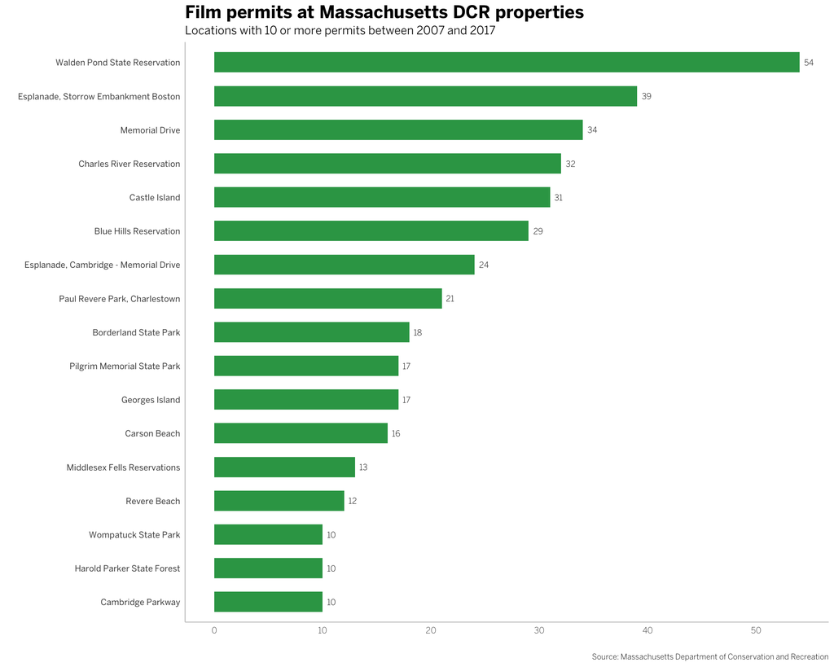

```r
library(ggplot2)
library(forcats)
library(scales)
library(extrafont)

ggplot(top_locations, aes(x=fct_reorder(DCR_location, Location_total), y=Location_total)) +
  geom_bar(stat="identity", fill="#31a354", width = .6) +
  geom_text(aes(label=Location_total), hjust=-.5, family="BentonSans Light", size=3) +
  coord_flip() +
  theme_classic() +
  scale_y_continuous(breaks = pretty_breaks(n = 6)) +
  labs(title="Film permits at Massachusetts DCR properties",
       subtitle="Locations with 10 or more permits between 2007 and 2017",
       y="", x="",
       caption="Source: Massachusetts Department of Conservation and Recreation") +
  theme(axis.line.y = element_line(color="grey80"),
        axis.line.x = element_line(color="grey80"),
        axis.ticks = element_blank(),
        axis.text.y = element_text(family="BentonSans Regular"),
        axis.text.x = element_text(family="BentonSans Light"),
        plot.title = element_text(size=18, family="BentonSans Bold"),
        plot.subtitle = element_text(size=12, family="BentonSans Book"),
        plot.caption = element_text(size=8, family="BentonSans Light", hjust=1))
```